# Diet Effects on Chicken Weights

## 1 Introduction

We observe weight measurements for 30 chicks over 21 days, denoted by:
$$y_{i,t},$$
where $i=1,\dots,30$ indexes the chicks, and $t\in\{0,2,4,\dots,20,21\}$ indexes the day of observation.

```r
library(ggplot2)
library(dplyr)

df <-
  datasets::ChickWeight |>
  filter(Diet %in% c(1, 2)) |>
  mutate(Diet = recode(Diet, `1` = "Diet 1", `2` = "Diet 2")) |>
  rename(Weight = weight)

df |>
  select(Chick, Diet) |>
  unique() |>
  count(Diet)
```

```
##     Diet  n
## 1 Diet 1 20
## 2 Diet 2 10
```

The chicks were assigned to one of two diets, with 20 chicks following Diet 1 and 10 chicks following Diet 2.

```r
library(tidyr)
df |>
  select(Chick, Diet, Time) |>
  count(Diet, Time) |>
  pivot_wider(names_from = Diet, values_from = n)
```

```
## # A tibble: 12 × 3
##     Time `Diet 1` `Diet 2`
##    <dbl>    <int>    <int>
##  1     0       20       10
##  2     2       20       10
##  3     4       19       10
##  4     6       19       10
##  5     8       19       10
##  6    10       19       10
##  7    12       19       10
##  8    14       18       10
##  9    16       17       10
## 10    18       17       10
## 11    20       17       10
## 12    21       16       10
```

Measurements for the chicks following Diet 2 are recorded consistently over the 21 days. Four chicks in Diet 1 have incomplete weight records by day 21.

We want to determine whether different diets determine different growth in the chicks.

## 2 Exploratory data analysis

### Growth curves

If different diets lead to different growth, we would expect different slopes in the growth curves of chicks.

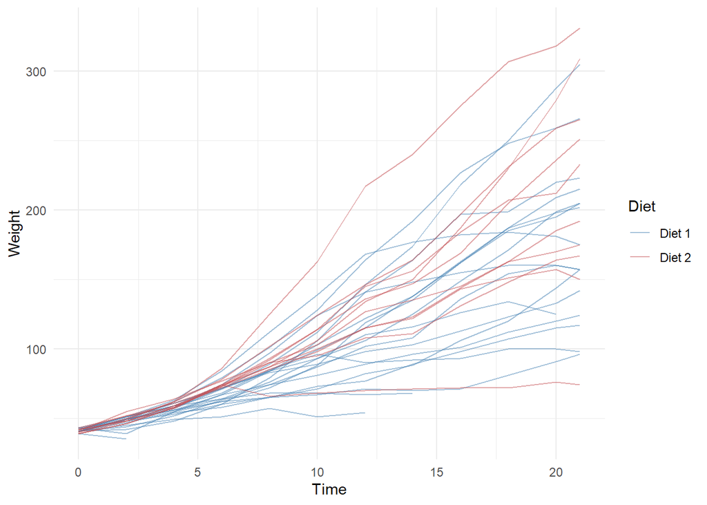

```r
df |>
  ggplot(aes(x = Time, y = Weight, group = Chick, color = Diet)) +
  geom_line(alpha = 0.5) +
  theme_minimal() +
  scale_color_manual(
    values = c("Diet 1" = "steelblue", "Diet 2" = "#C44E52"))
```

### Boxplot

Equivalently, one group of chicks would exhibit higher overall weights at the terminal day, $t=21$.

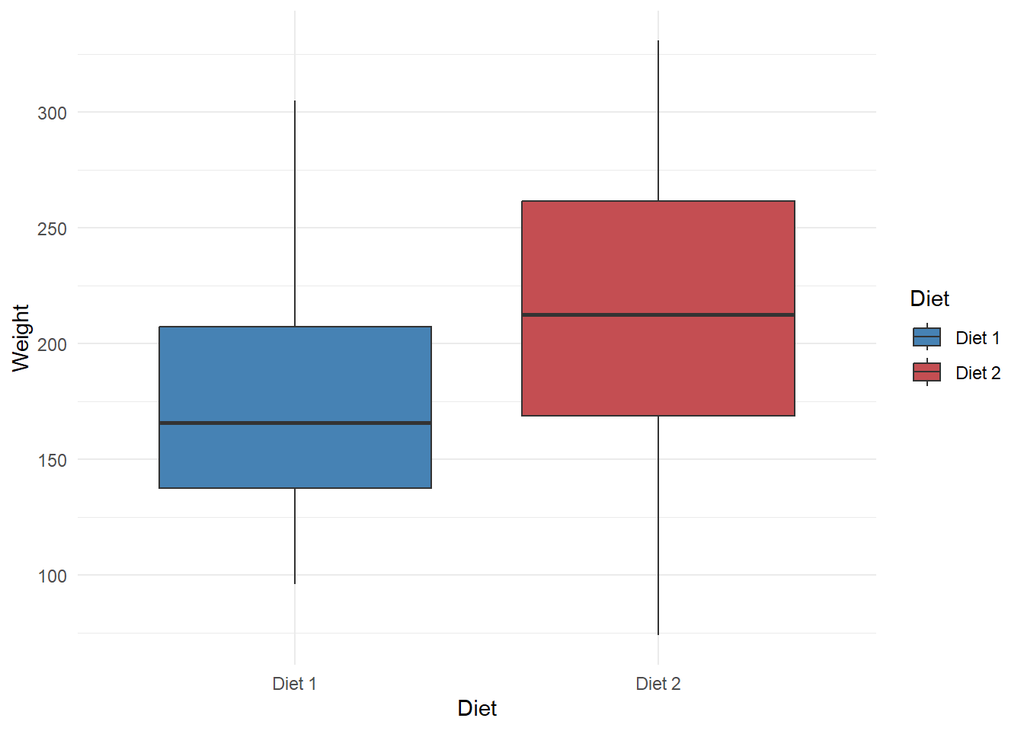

```r
df |>
  group_by(Chick) |>
  filter(Time == 21) |>
  ggplot(aes(x = Diet, y = Weight, fill = Diet)) +
  geom_boxplot() +
  theme_minimal() +
  scale_fill_manual(
    values = c("Diet 1" = "steelblue", "Diet 2" = "#C44E52"))
```

While Diet 2 appears to deliver a higher median weight than Diet 1, the difference can be small relative to the variability.

## 3 Simple comparison

### QQ plots

Visually, the final weight distributions under both diets appear close to Gaussian.

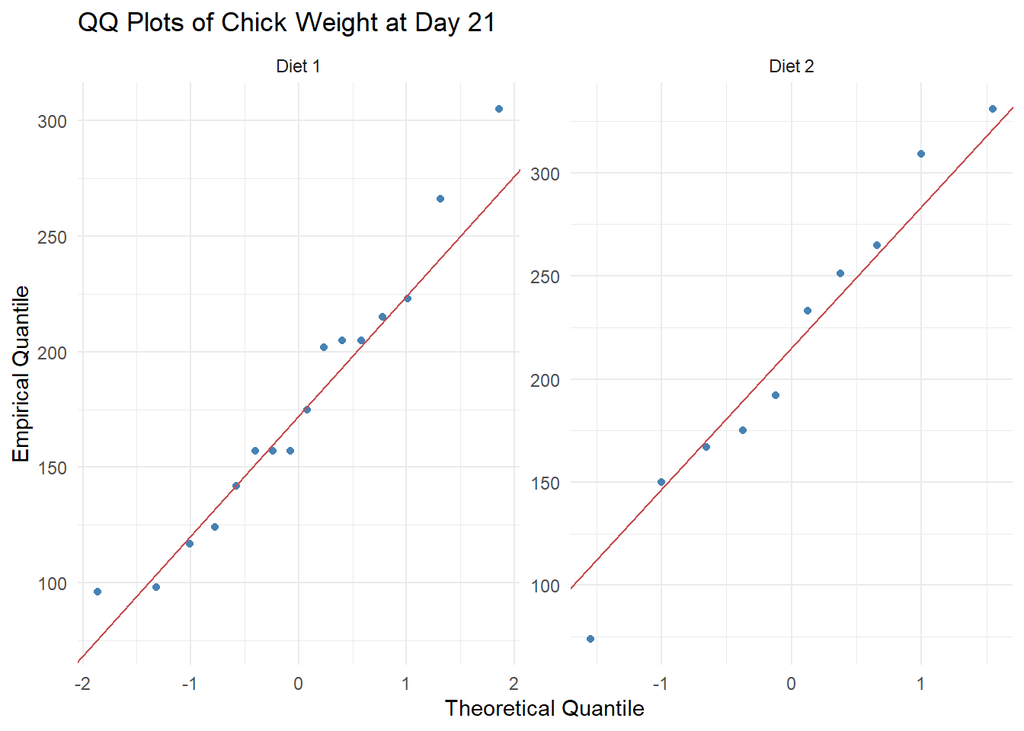

```r
df |>
  filter(Time == 21) |>
  ggplot(aes(sample = Weight)) +
  stat_qq(color = "steelblue") +
  stat_qq_line(color = "#C44E52") +
  facet_wrap(~ Diet, scales="free") +
  theme_minimal() +
  labs(
    x = "Theoretical Quantile",
    y = "Empirical Quantile",
    title="QQ Plots of Chick Weight at Day 21")
```

### Test

We can test equality in the means of two Gaussian populations with (possibly) unequal variances using the *Welch’s t-test*.

$H_0$: chicks on different diets have the same weight on $t=21$;

$H_1$: chicks on different diets have different weights on $t=21$.

```r
df |>
  group_by(Chick) |>
  filter(Time == 21) %>%
  t.test(Weight ~ Diet, data = .)
```

```
##
##  Welch Two Sample t-test
##
## data:  Weight by Diet
## t = -1.2857, df = 15.325, p-value = 0.2176
## alternative hypothesis: true difference in means between group Diet 1 and group Diet 2 is not equal to 0
## 95 percent confidence interval:
##  -98.09263  24.19263
## sample estimates:
## mean in group Diet 1 mean in group Diet 2
##               177.75               214.70
```

We fail to reject $H_0$.

## 4 Linear regression

The previous approach discards information for $t<21$.

We consider the linear model:

$$y_{i,t} = \beta_0 + \beta_1 t + \beta_2 \, \mathbf{1}_{\{ \text{Diet}_i
= 2 \}} + \varepsilon_{i,t},$$

where

$$\mathbf{1}_{\{ \text{Diet}_i = 2 \}} =
\begin{cases}
1 & \text{if chick } i \text{ is on Diet 2}, \\
0 & \text{otherwise}.
\end{cases}$$

### Estimation and inference

- Ordinary least squares estimation;
- Inference under Gaussian assumption, $\varepsilon\sim\mathcal{N}(0,\Sigma)$;

```r
naive_lm =
  df %>%
  lm(Weight ~ Time + Diet, data = .)

summary(naive_lm)
```

```
##
## Call:
## lm(formula = Weight ~ Time + Diet, data = .)
##
## Residuals:
##      Min       1Q   Median       3Q      Max
## -123.938  -15.709   -1.197   15.902  133.062
##
## Coefficients:
##             Estimate Std. Error t value Pr(>|t|)
## (Intercept)  24.3476     3.9332   6.190 1.75e-09 ***
## Time          7.4699     0.2929  25.504  < 2e-16 ***
## DietDiet 2   16.7229     4.1405   4.039 6.65e-05 ***
## ---
## Signif. codes:  0 '***' 0.001 '**' 0.01 '*' 0.05 '.' 0.1 ' ' 1
##
## Residual standard error: 36.47 on 337 degrees of freedom
## Multiple R-squared:  0.6666, Adjusted R-squared:  0.6646
## F-statistic: 336.9 on 2 and 337 DF,  p-value: < 2.2e-16
```

- The output considers $\Sigma = \sigma^2I$.

### Diagnostics 1: residuals vs fitted values

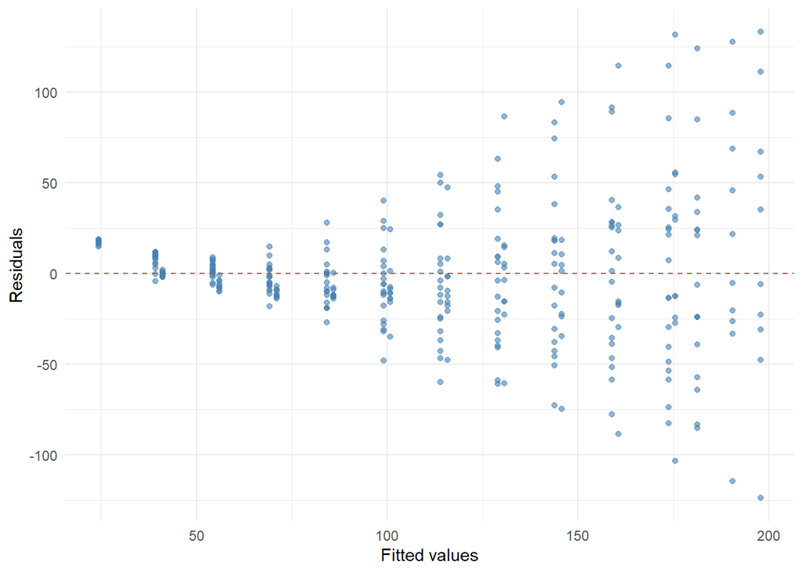

```r
res_diagnostics_heterosced <- function(model){
  data.frame(
  fitted_values = fitted(model),
  residuals = residuals(model)) |>
  ggplot(aes(x = fitted_values, y = residuals)) +
  geom_point(color = "steelblue", alpha = 0.6) +
  geom_hline(yintercept = 0, color = "#C44E52", linetype = "dashed") +
  labs(x = "Fitted values", y = "Residuals") +
  theme_minimal()
}

res_diagnostics_heterosced(naive_lm)
```

- Linearity of the conditional mean appears adequate;
- Presence of *heteroscedasticity*: covariates do not capture that variability in weight increases with the weight itself.

### Diagnostics 2: autocorrelation of residuals

Repeated measurements for the same chicks over time induce *autocorrelation* in the residuals.

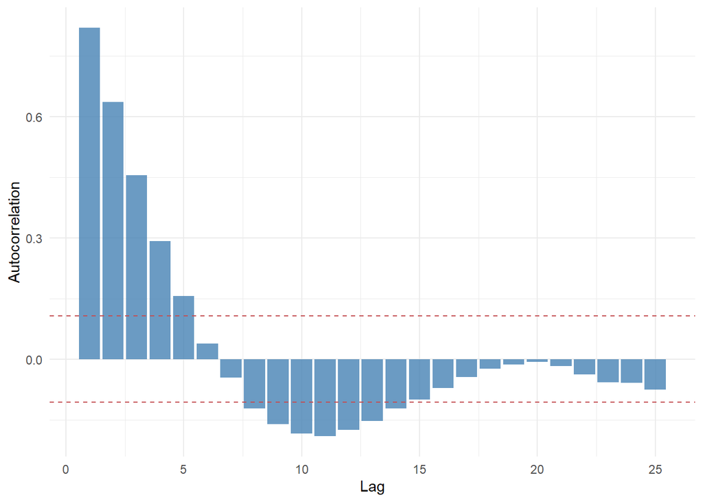

```r
res_diagnostics_autocorr <- function(model){
  res = residuals(model)
  tmp <- acf(res, plot = FALSE)
  foo <- 1.96 / sqrt(length(res))
  data.frame(Lag = tmp$lag[-1], ACF = tmp$acf[-1]) |>
    ggplot(aes(x = Lag, y = ACF)) +
    geom_col(fill = "steelblue", alpha = 0.8) +
    geom_hline(yintercept = c(foo, - foo), linetype = "dashed", color = "#C44E52") +
    labs(x = "Lag", y = "Autocorrelation") +
    theme_minimal()
}

res_diagnostics_autocorr(naive_lm)
```

### Clustered standard errors

- Autocorrelation and heteroscedasticity robust standard errors;
- Block diagonal covariance matrix of residuals;
- $Cov(\varepsilon_{i,t},\varepsilon_{i,s})\ne 0,\forall t,s$ and $Cov(\varepsilon_{i,t},\varepsilon_{j,s})= 0,\forall i\ne j, t,s$.

```r
library(sandwich)
library(lmtest)
cluster_se <- vcovCL(naive_lm, cluster = ~ Chick)
coeftest(naive_lm, vcov = cluster_se)
```

```
##
## t test of coefficients:
##
##             Estimate Std. Error t value  Pr(>|t|)
## (Intercept)  24.3475     5.1615  4.7171  3.51e-06 ***
## Time          7.4699     0.6687 11.1707 < 2.2e-16 ***
## DietDiet 2   16.7230    10.9349  1.5293    0.1271
## ---
## Signif. codes:  0 '***' 0.001 '**' 0.01 '*' 0.05 '.' 0.1 ' ' 1
```

## 5 Mixed-effects model

Explicitly model within-chick variability adding random effects, $b_{0,i}$ and $b_{1,i}$, to the linear model:

$$y_{i,t} = \beta_0 + \beta_1 t + \beta_2 \, \mathbf{1}_{\{ \text{Diet}_i
= 2 \}}
+ b_{0,i} + b_{1,i} t + \varepsilon_{i,t},$$

$$\begin{pmatrix}
b_{0i} \\
b_{1i}
\end{pmatrix}
\sim \mathcal{N}\left(
\begin{pmatrix}
0 \\
0
\end{pmatrix},
\begin{pmatrix}
\sigma_0^2 & \sigma_{01} \\
\sigma_{01} & \sigma_1^2
\end{pmatrix}
\right), \quad
\varepsilon_{i,t} \sim \mathcal{N}(0, \sigma^2).$$

Advantages:

- Explicit covariance structure;
- Efficiency gains in estimation.

### Estimation and inference

- Estimation via Restricted Maximum Likelihood;
- Inference for fixed effects using t-statistics and degrees-of-freedom adjustments.

```r
library(lmerTest)
mixed_lm <- lmer(Weight ~ Time + Diet + (Time | Chick), data = df)
summary(mixed_lm)
```

```
## Linear mixed model fit by REML. t-tests use Satterthwaite's method [
## lmerModLmerTest]
## Formula: Weight ~ Time + Diet + (Time | Chick)
##    Data: df
##
## REML criterion at convergence: 2751.1
##
## Scaled residuals:
##     Min      1Q  Median      3Q     Max
## -3.0438 -0.4918 -0.0135  0.4813  3.9754
##
## Random effects:
##  Groups   Name        Variance Std.Dev. Corr
##  Chick    (Intercept) 139.21   11.799
##           Time         13.46    3.669   -0.95
##  Residual             125.47   11.201
## Number of obs: 340, groups:  Chick, 30
##
## Fixed effects:
##             Estimate Std. Error      df t value Pr(>|t|)
## (Intercept)  31.1782     2.5751 33.0923  12.108 1.05e-13 ***
## Time          7.0571     0.6818 28.9749  10.351 3.03e-11 ***
## DietDiet 2    2.4023     2.3956 27.5829   1.003    0.325
## ---
## Signif. codes:  0 '***' 0.001 '**' 0.01 '*' 0.05 '.' 0.1 ' ' 1
##
## Correlation of Fixed Effects:
##            (Intr) Time
## Time       -0.839
## DietDiet 2 -0.314 -0.006
## optimizer (nloptwrap) convergence code: 0 (OK)
## Model failed to converge with max|grad| = 0.00366569 (tol = 0.002, component 1)
##   See ?lme4::convergence and ?lme4::troubleshooting.
```

### Diagnostics

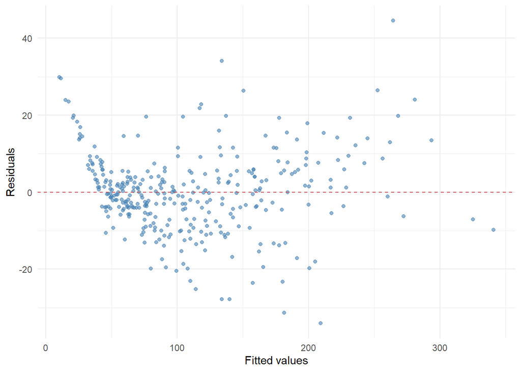

```r
res_diagnostics_heterosced(mixed_lm)
```

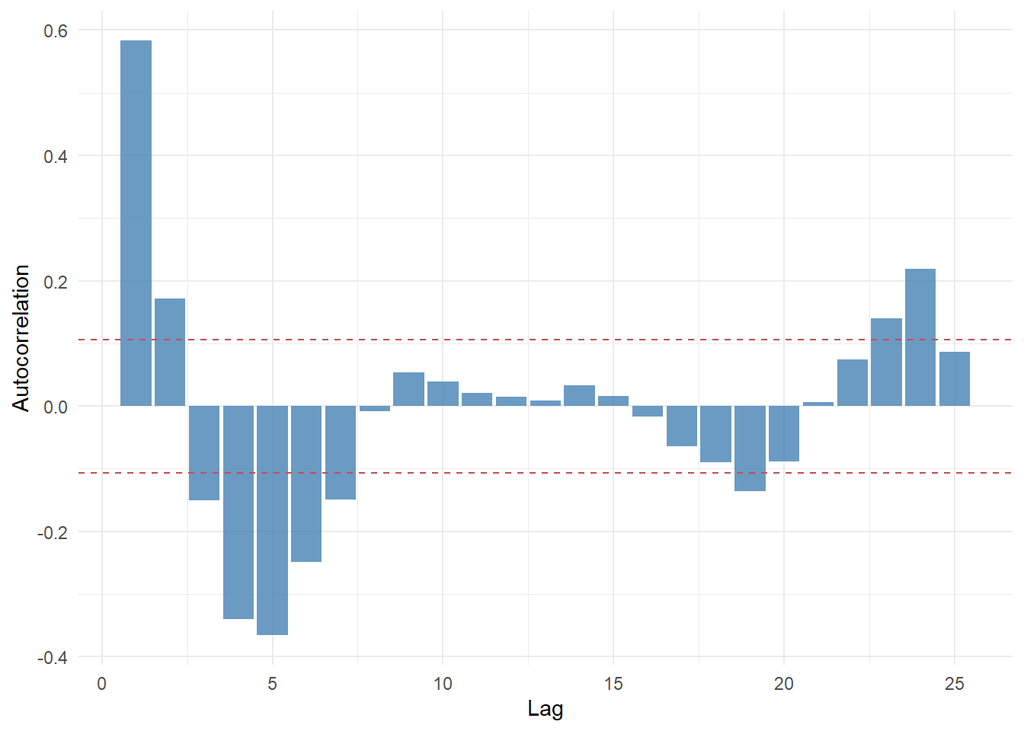

```r
res_diagnostics_autocorr(mixed_lm)
```

## 6 Summary

- Chicks gain around 7 grams per day according to both fixed- and mixed-effects models;
- Chicks following Diet 2 exhibit higher average growth, however this effect is not significant;
- According to the mixed-effects model, chicks that are bigger at birth display lower growth over time.